# Variability and Standardizing Lab

## Question 1 – Calculation

For the following data set, calculate the mean and standard deviation using the formulas: $\{-4, -1, 1, 2, 7\}$.

(Hint: write down or circle information as you learn it, work through smaller calculations as needed)

## Question 2 – Height Comparison with Z-scores

Let’s finish answering the height comparison question in the notes. The average height of males in the US is 69 inches with a std. dev. of 2.8 inches. The average height of females in the US is 64 inches with a standard deviation of 2.4 inches.

**Part A**: Label the pieces of information in this setup with notation we’ve seen for means and standard deviations.

**Part B**: Compute the Z-score for a male with a height of 72 inches and for a female with a height of 66.5 inches.

**Part C**: Interpret the z-scores in Part B.

**Part D**: Which of these two people would be considered taller relative to their sex?

# Question 3 – Standard Deviation Intuition

For this problem we will return to the college dataset we’ve used previously.

We are going to use the `Net_Tuition` variable and practice some ideas related to variability.

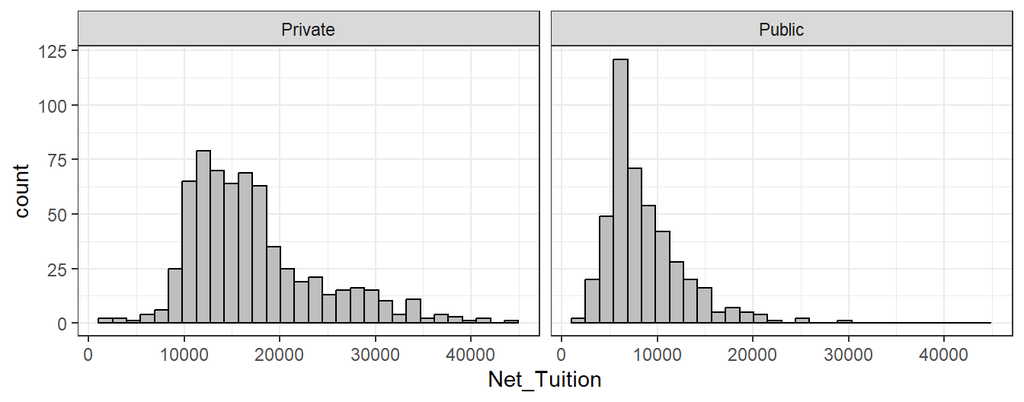

**Part A**: Why would we *not* want to use mean and standard deviation to describe the histograms for each of these groups? (Regardless, we will use these to practice our concepts)

**Part B**: Compare the variability of both groups. Which would have a larger standard deviation? Explain.

```r
library(dplyr)
college <- read.csv("https://collinn.github.io/data/college2019.csv")
# code to get values
college %>% filter(Type=="Private") %>% pull(Net_Tuition) %>% mean()
```

```
## [1] 17243.76
```

```r
college %>% filter(Type=="Private") %>% pull(Net_Tuition) %>% sd()
```

```
## [1] 6828.921
```

**Part E**: Suppose I add an observation for another college to the Private college data, which is an outlier with a large Net Tuition of $50,000. What would happen to the std. dev.?

**Part F**: Suppose I add an observation for another college to the Private college data, which is an outlier with a small Net Tuition of $2,000. What would happen to the std. dev.?

# Question 4 (MCAT revisited)

The following is a distribution of MCAT scores, an exam frequently used in selection for medical schools. The mean score is 501 and the standard deviation is 11. MCAT scores are not perfectly Normal, but we can use the Normal distribution to get estimates of probabilities/percentages.

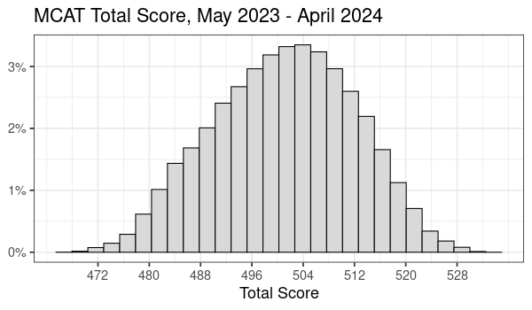

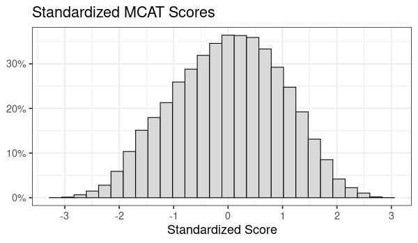

**Part A**: Some schools have an MCAT admission cutoff of 494. What is the chance of picking a person who got a score less than 494? First compute a Z-score, then use `pnorm`.

**Part B**: University of Iowa’s College of Medicine’s students have an average MCAT of 515. Roughly what overall percent of people got an MCAT score of 515 or more? Use a Z-score to help you find this using `pnorm`.

**Part C**: Roughly what score would someone need to be in the top 25% of test-takers? A Z-score calculation will make this easy.